# Analysis on NFT sales

Blind

2/21/2022

# Introduction

A non-fungible token (NFT) is a non-interchangeable unit of data stored on a blockchain that can be sold and traded. Various types of NFT data units may be associated with digital files such as photos, videos, and audio, or skins in video games like Counter Strike: Global Offensive. Since each NFT has a unique identifier, they is different from cryptocurrencies, such as bitcoin, which only exists as a chain of transactions. To analyze the recent social interest in NFTs, we collected data from NonFungible.com, one of the largest databases of blockchain gaming and crypto-collectible market activity. The sales data, described on their website as, **“Total usd spent on completed sales”**. This data ranges from June 22nd 2017 to February 20th 2022 with the unit of USD. Additionally, we collected Google Trends data described as representing the average weekly searches on the *topic* of NFT_s, which notably is *not* limited to the query “nft”. We will examine both datasets concurrently to establish a relationship between the sales data and the trending data. As opposed to stocks, NFTs are given value by the people that buy and sell them. With our analysis we wish to explore how public interest and total money in NFTs is related.

# Data Preprocessing

The Google trend data takes the average over a week, but we noticed that the most of data starting in 2017 contain zero terms. These terms will be unhelpful for analysis. From the data, we assume that since the social popularity of NFT has not been recognized in 2017, this time frame is not relevant to our exploration’s question, so we picked the data starting from September 27th 2020 to February 20th 2022 for analysis. The sales data of NFT is given daily, which corresponds to the 512 observations that streched over the period of valid Google Trends data.

# Exploratory Data Analysis

However, one problem is the Google trend only counts data weekly, which is less precise than our daily sales, we decided to smooth it using the generalized linear model (GAM) with natural spline. We set the number of knots as large as possible (30) to preserve the underlying trend.

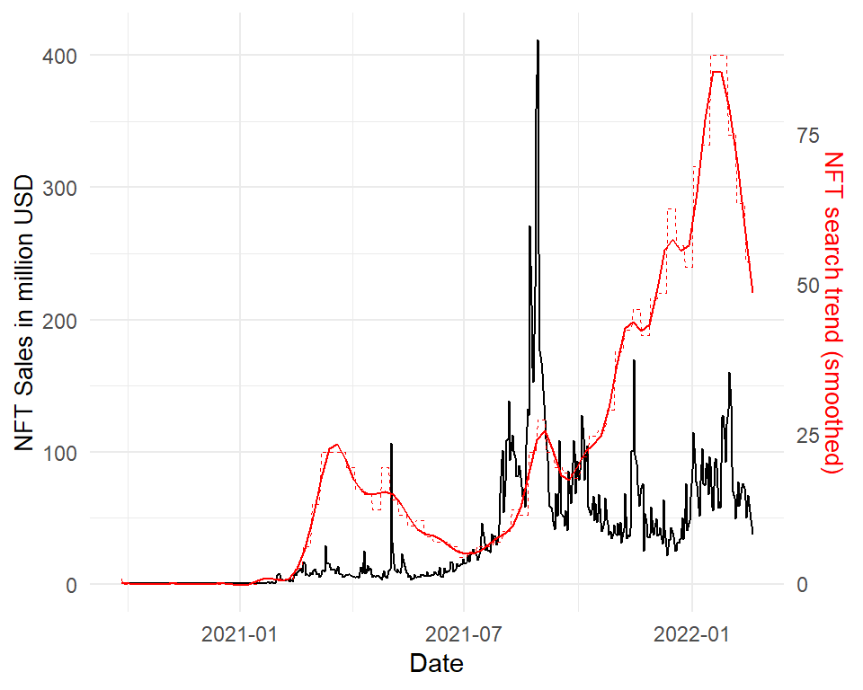

Figure 1: General Visualization for NFT sales and search trend

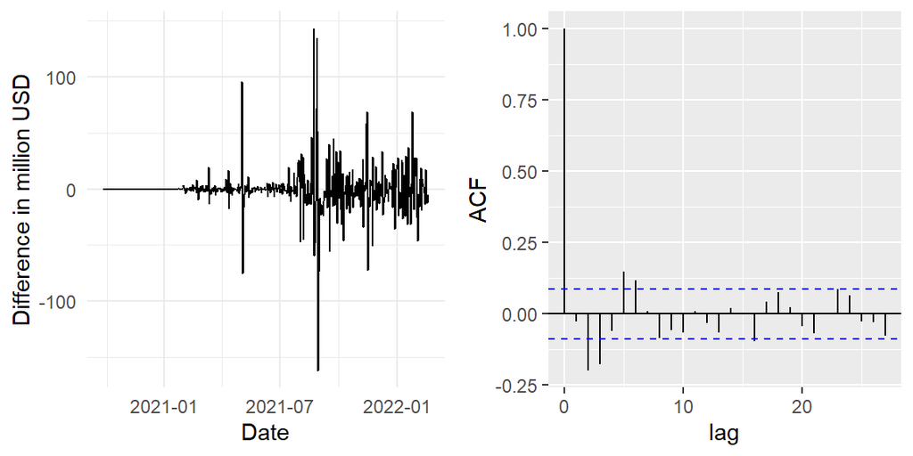

# ARIMA fitting

We implemented a loop similar to the procedure introduced in lecture to fit ARIMA models with all combinations of AR and MA structures, specifically from $ARIMA(0,1,0)$ to $AR(5,1,5)$, using AIC as the model selection criteria. Our fitting results are the following:

|  | MA0 | MA1 | MA2 | MA3 | MA4 | MA5 |
| --- | --- | --- | --- | --- | --- | --- |
| AR0 | 4452.30 | 4453.72 | 4426.60 | 4421.22 | 4422.42 | 4415.05 |
| AR1 | 4453.96 | 4427.03 | 4423.07 | 4423.03 | 4422.19 | 4415.70 |
| AR2 | 4435.41 | 4419.01 | 4406.77 | 4408.53 | 4414.75 | 4409.53 |
| AR3 | 4417.54 | 4415.21 | 4408.21 | 4407.81 | 4409.74 | 4410.85 |
| AR4 | 4411.04 | 4412.01 | 4411.50 | 4409.62 | 4411.52 | 4412.86 |
| AR5 | 4411.07 | 4411.33 | 4411.46 | 4410.30 | 4412.26 | 4403.16 |

```
##
## Call:
## arima(x = nfts$`Sales USD`/1e+06, order = c(2, 1, 2))
##
## Coefficients:
##          ar1      ar2      ma1     ma2
##       0.9592  -0.6983  -1.0601  0.5779
## s.e.  0.1223   0.0684   0.1476  0.1017
##
## sigma^2 estimated as 324.6:  log likelihood = -2198.39,  aic = 4406.77
```

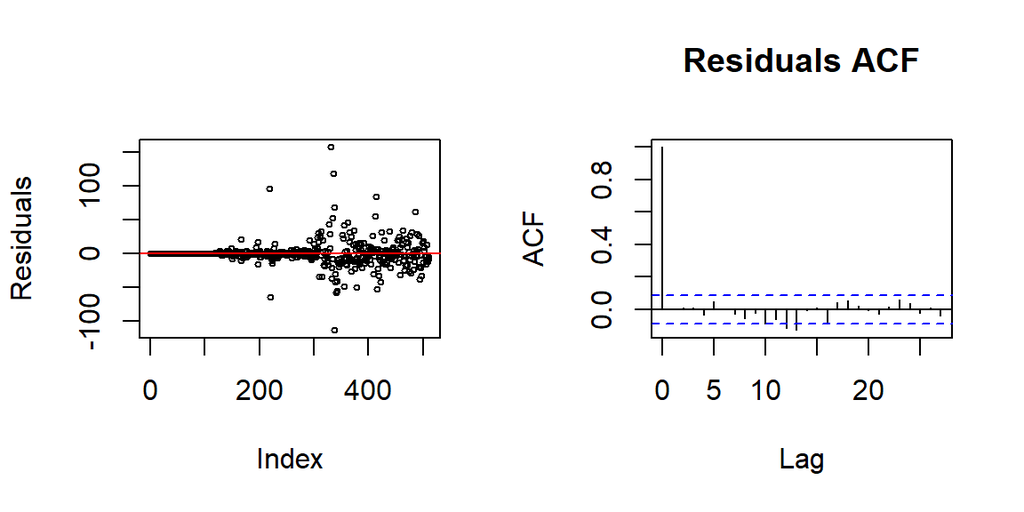

Figure 3: ARIMA(2,1,2) Residuals and its ACF

The residual and ACF plots, however, give relatively desirable results for our assumptions. Residuals center at 0 with few outilers. Alsom there seems to be no significant correlation between the residuals.

# Frequent and Seasonailty

Another intuitive guess about the NFT market, we think, is that it also experience some periodicity like the normal market. Perhaps people tend to trade more in weekdays rather than weekends, or most of the deals take place on the second half of every month. Hence, we want to check the spectrum to find possible periodicity evidences.

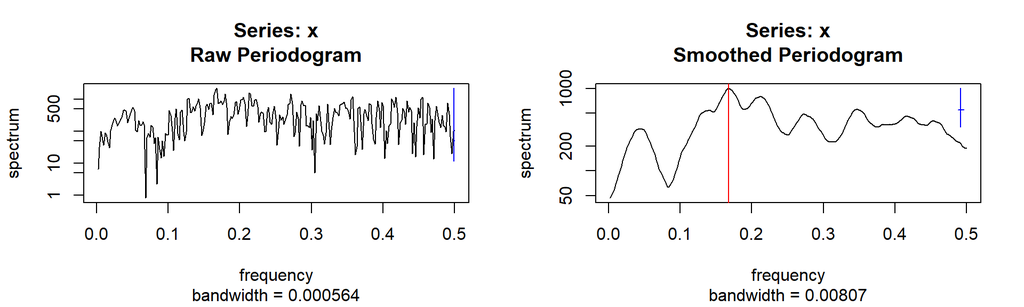

Figure 4: Unsmoothed and span-smoothed spectrum

# Trend analysis

Our ultimate goal for our analysis is to find potential trend for NFT trade and link it with the search trend. Hence, in this part, we try to focus back on our original sales data rather than the difference version, and try to regress the search trend on it. In general, we assume our model as:
$$Y_i = \beta_0 + \beta_1+\epsilon_i,\quad \epsilon_i\sim ARMA(p,q)$$

And our comparison model with regression on the weekly trend gives the following result:

```
##
## Call:
## arima(x = nfts$`Sales USD`/1e+06, order = c(4, 0, 2), xreg = nfts$nft_s)
##
## Coefficients:
##          ar1      ar2     ar3      ar4      ma1     ma2  intercept  nfts$nft_s
##       2.4616  -2.4026  1.0607  -0.1473  -1.6103  0.9036    13.9618      0.8821
## s.e.  0.0633   0.1255  0.1080   0.0470   0.0502  0.0495    10.7378      0.3014
##
## sigma^2 estimated as 309.4:  log likelihood = -2191.57,  aic = 4401.13
```

# Truncated analysis after Boom

The huge NFT boom in August really draws our attention. Due to this actively-traded period, our model is kind of unstable. Also, since the trend data suggests that the word ‘NFT’ becomes increasingly popular since October 2021, in this part, we tried to remove all the data before the boom ends(September 7, 2021) and try fitting using the rest 166 observations since we want to make our model more stable using a fairly enough sample. We hope the result will be more favorable:

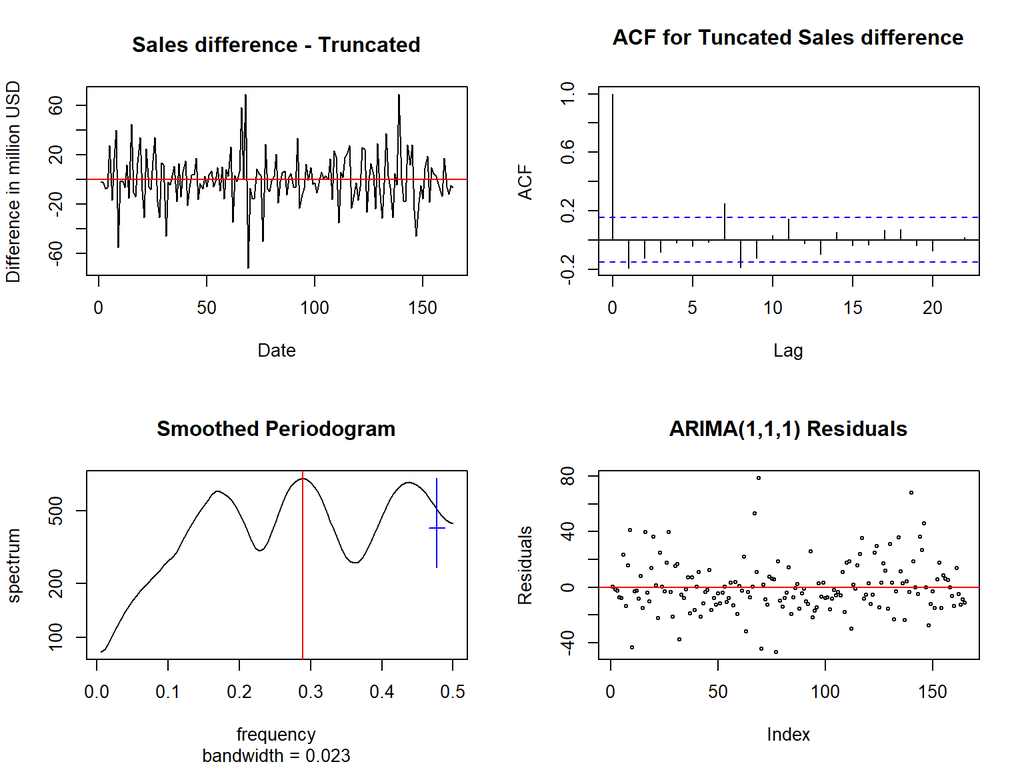

Figure 5: Top Left: Differce series; Top Right: ACF of difference series; Bottom Left: Smooth Periodigram; Bottom Right: ARIMA(1,1,1) Residuals

However, the results have approximately no difference. The difference series still looks stationary, with a new $ARMA(1,1)$ model, and we should not add a seasonal term into it.

The interesting part lies in the regression part, where we suggest using a $ARMA(1,0)$ model for the sale trend. The new $\beta_1$ estimate (from $ARMA(1,0)$) gives 0.2477, with 95% confidence interval [-0.1608, 0.6561], which means the trend is not that informative, corresponding to a likelihood ratio test statistic of 1.36.

[output not shown]

This may because the NFT buzz drops mid-January 2022. When the NFT sales drops in a lag. Also, although the search trend did not come to the same level as the NFT sales rise in the August boom, they do proceeds in the same direction. Thus, it is also informative and removing this time period may not be a good choice.

# Conclusion

After analyzing the Google Trends data and the NonFungible.com Market data from September 27th 2020 to February 20th 2022, we draw the following conclusions:

We tried to link the Google Trend data to the sales in order to find a link. The $ARMA(4,2)$ model turns out to validate our assumption that the increasing searching trend for NFT does facilitate sales.

Due to the prosperity of the NFT sales in August 2021, our model could be unstable. To examine the trend with extra caution, we picked the data after the huge sales (September 7, 2021) and fit the 166 observations. The results turned out to be slightly different to the previous one: the $ARMA(1,1)$ model without a seasonality. However, the regression part suggests that the trend is not informative since the heat of NFT drops off mid-January 2022.

# Acknowledgements

1. [Non-fungible token from Wikipedia, the free encyclopedia](https://en.wikipedia.org/wiki/Non-fungible_token)
2. [NonFungible Market History](https://nonfungible.com/market/history)
3. [Google Trends](https://trends.google.com/trends/?geo=US)
4. [Lecture slides and notes](https://ionides.github.io/531w22/)
5. [Models for Bitcoin Prices](https://ionides.github.io/531w21/midterm_project/project01/project.html)